# Unit07--Pandas的基本資料結構Series、DataFrame操作【老師上課資料】

【臺北大學】Python程式設計  
【授課老師】陳祥輝 (Email : HsiangHui.Chen@gmail.com)  
【facebook】[陳祥輝老師的臉書 (歡迎加好友)](https://goo.gl/osivhx)  
【參考書籍】[從零開始學Python程式設計（適用Python 3.5以上）](http://www.drmaster.com.tw/Bookinfo.asp?BookID=MP31821)  
【主要議題】Pandas的基本資料結構Series/DataFrame操作

【重點提要】

###### Pandas : Data structures & analysis

Pandas 提供的重要資料結構

- Series：用來處理時間序列相關的資料(如感測器資料等)，主要為建立索引的一維陣列。
- DataFrame：用來處理結構化(Table like)的資料，有列索引(indexes)與欄標籤(columns)的二維資料集，例如關聯式資料庫、CSV 等等。
- Panel：用來處理有資料及索引、列索引與欄標籤的三維資料集。

Pandas 提供的資料型態

- Categorical
  - Norminal
  - Ordinal

Pandas的DataFrame

- DataFrame的基本瀏覽
- DataFrame的列(row)、行(column)操作
- DataFrame的各種資料篩選
- DataFrame的groupby
- DataFrame的concat(如同R語言的rbind與Cbind)
- DataFrame的merge(inner、outer、left以及right)，如同SQL的join
- DataFrame duplicate rows的DataFrame.drop_duplicates()
- DataFrame匯出至不同檔案格式

```python
# -*- coding: utf-8 -*-
from platform import python_version
import os, time, glob, socket
import pandas as pd
import numpy as np
import matplotlib.pyplot as plt

print("【日期時間】{}".format(time.strftime("%Y/%m/%d %H:%M:%S")))
print("【工作目錄】{}".format(os.getcwd()))
print("【主機名稱】{} ({})".format(socket.gethostname(),socket.gethostbyname(socket.gethostname())))
print("【Python】{}".format(python_version()))

%autosave 120
```

```
【日期時間】2021/05/18 13:26:41
【工作目錄】c:\【臺北大學系列課程】\【臺北大學三峽校區】1092Python程式設計\DaleChen
【主機名稱】DBSERVER (192.168.0.16)
【Python】3.8.5
```

```
Autosaving every 120 seconds
```

### Pandas的Series

```python
[1, 3, 5] + [2, 4, 6]
```

```
[1, 3, 5, 2, 4, 6]
```

```python
pd.Series(range(15))
```

```
0      0
1      1
2      2
3      3
4      4
5      5
6      6
7      7
8      8
9      9
10    10
11    11
12    12
13    13
14    14
dtype: int64
```

```python
srs1 = pd.Series(range(11, 16))
srs2 = pd.Series(range(21, 26))
print(srs1)
print(srs2)
print(srs1+srs2)
```

```
0    11
1    12
2    13
3    14
4    15
dtype: int64
0    21
1    22
2    23
3    24
4    25
dtype: int64
0    32
1    34
2    36
3    38
4    40
dtype: int64
```

```python
srs1 = pd.Series(range(11, 16), index=range(1, 6))
srs2 = pd.Series(range(21, 26), index=range(3, 8))
print(srs1)
print(srs2)
print(srs1+srs2)
```

```
1    11
2    12
3    13
4    14
5    15
dtype: int64
3    21
4    22
5    23
6    24
7    25
dtype: int64
1     NaN
2     NaN
3    34.0
4    36.0
5    38.0
6     NaN
7     NaN
dtype: float64
```

#### 比較 list 與 pd.Series 的 index

```python
lst = list(range(11, 21))
print(lst)
print(lst[[3, 4, 7]])         # 不允許離散取值
```

```
[11, 12, 13, 14, 15, 16, 17, 18, 19, 20]
```

```
---------------------------------------------------------------------------
TypeError                                 Traceback (most recent call last)
<ipython-input-9-c71115279c1d> in <module>
      1 lst = list(range(11, 21))
      2 print(lst)
----> 3 print(lst[[3, 4, 7]])         # 離散取值

TypeError: list indices must be integers or slices, not list
```

```python
srs  = pd.Series(range(11, 21))
print(srs[:3])
print(srs[[3, 5, 9]])         # 允許離散取值
```

```
0    11
1    12
2    13
dtype: int64
3    14
5    16
9    20
dtype: int64
```

```python
scores = pd.Series(np.random.randint(0, 101, 50))
print(type(scores))
print(scores.dtype)
```

```
<class 'pandas.core.series.Series'>
int32
```

#### 轉換資料型態

```python
scores = scores.astype(np.int16)
print(scores.dtype)
```

```
int16
```

#### pd.Series 有很多的基本統計量可以使用

```python
scores = pd.Series(np.random.randint(0, 101, 50))
scores[3,5,7] = np.nan                               # 模擬有三筆資料是 missing value
print(scores.mean(skipna=True))
print(scores.std(skipna=True))
print(scores.var(skipna=True))
print(scores.mode())
print(scores.median(skipna=True))
print(scores.quantile(q=[0, 0.25, 0.5, 0.75, 1]))
```

```
42.1063829787234
28.548383067403
815.0101757631824
0     3.0
1    35.0
2    52.0
dtype: float64
35.0
0.00     1.0
0.25    18.0
0.50    35.0
0.75    67.5
1.00    95.0
dtype: float64
```

#### 查看有幾個 missing value

```python
print(scores.isna().sum())
```

```
3
```

#### 使用 pd.Series 計算大數法則

- https://zh.wikipedia.org/wiki/大數法則

```python
n = 10
trials = pd.Series(np.random.choice(range(1, 7), n))
print(list(trials))
print(list(trials.cumsum()))
print(list(pd.Series(range(1, n+1))))
print(list(trials.cumsum() / pd.Series(range(1, n+1))))
```

```
[5, 6, 3, 3, 1, 5, 1, 4, 4, 2]
[5, 11, 14, 17, 18, 23, 24, 28, 32, 34]
[1, 2, 3, 4, 5, 6, 7, 8, 9, 10]
[5.0, 5.5, 4.666666666666667, 4.25, 3.6, 3.8333333333333335, 3.4285714285714284, 3.5, 3.5555555555555554, 3.4]
```

### Pandas的DataFrame

```python
fname = r'C:\Data\PyData\AirQty2016-06-01_UTF8.csv'
airQty = pd.read_csv(fname, sep=',', encoding='utf-8', engine='python')
airQty.head(3)
```

|  | SiteName | County | PSI | MajorPollutant | Status | SO2 | CO | O3 | PM10 | PM2.5 | NO2 | WindSpeed | WindDirec | FPMI | NOx | NO | PublishTime |
| --- | --- | --- | --- | --- | --- | --- | --- | --- | --- | --- | --- | --- | --- | --- | --- | --- | --- |
| 0 | 麥寮 | 雲林縣 | 36 | NaN | 良好 | 1.2 | 0.11 | 10.0 | 35.0 | 7 | 4.5 | 2.2 | 182.0 | 1 | 6.78 | 2.30 | 2016/6/1 02:00 |
| 1 | 關山 | 臺東縣 | 23 | NaN | 良好 | 1.2 | NaN | 5.1 | 21.0 | 7 | 3.6 | 0.7 | 232.0 | 1 | 4.89 | 1.32 | 2016/6/1 02:00 |
| 2 | 馬公 | 澎湖縣 | 16 | NaN | 良好 | 0.8 | 0.09 | 20.0 | 5.0 | 2 | 1.7 | 2.5 | 173.0 | 1 | 3.26 | 1.53 | 2016/6/1 02:00 |

```python
print(type(airQty))
print(airQty.shape)
print(airQty.shape[0])
print(airQty.shape[1])
print(airQty.columns)
print(airQty.dtypes)
```

```
<class 'pandas.core.frame.DataFrame'>
(76, 17)
76
17
Index(['SiteName', 'County', 'PSI', 'MajorPollutant', 'Status', 'SO2', 'CO',
       'O3', 'PM10', 'PM2.5', 'NO2', 'WindSpeed', 'WindDirec', 'FPMI', 'NOx',
       'NO', 'PublishTime'],
      dtype='object')
SiteName           object
County             object
PSI                 int64
MajorPollutant     object
Status             object
SO2               float64
CO                float64
O3                float64
PM10              float64
PM2.5               int64
NO2               float64
WindSpeed         float64
WindDirec         float64
FPMI                int64
NOx               float64
NO                float64
PublishTime        object
dtype: object
```

```python
airQty.memory_usage(index=False)
```

```
SiteName          608
County            608
PSI               608
MajorPollutant    608
Status            608
SO2               608
CO                608
O3                608
PM10              608
PM2.5             608
NO2               608
WindSpeed         608
WindDirec         608
FPMI              608
NOx               608
NO                608
PublishTime       608
dtype: int64
```

```python
airQty.memory_usage(index=False).sum()
```

```
10336
```

#### 探索 missing value

```python
airQty.isna()
```

|  | SiteName | County | PSI | MajorPollutant | Status | SO2 | CO | O3 | PM10 | PM2.5 | NO2 | WindSpeed | WindDirec | FPMI | NOx | NO | PublishTime |
| --- | --- | --- | --- | --- | --- | --- | --- | --- | --- | --- | --- | --- | --- | --- | --- | --- | --- |
| 0 | False | False | False | True | False | False | False | False | False | False | False | False | False | False | False | False | False |
| 1 | False | False | False | True | False | False | True | False | False | False | False | False | False | False | False | False | False |
| 2 | False | False | False | True | False | False | False | False | False | False | False | False | False | False | False | False | False |
| 3 | False | False | False | True | False | False | False | False | False | False | False | False | False | False | False | False | False |
| 4 | False | False | False | True | False | False | False | False | False | False | False | False | False | False | False | False | False |
| ... | ... | ... | ... | ... | ... | ... | ... | ... | ... | ... | ... | ... | ... | ... | ... | ... | ... |
| 71 | False | False | False | True | False | False | False | False | False | False | False | False | False | False | False | False | False |
| 72 | False | False | False | True | False | False | False | False | False | False | False | False | False | False | False | False | False |
| 73 | False | False | False | True | False | False | False | False | False | False | False | False | False | False | False | False | False |
| 74 | False | False | False | True | False | False | False | False | False | False | False | False | False | False | False | False | False |
| 75 | False | False | False | True | False | False | False | False | False | False | False | False | False | False | False | False | False |

76 rows × 17 columns

```python
sum([True, True, False])   # True 當成 1, False 當成是 0
```

```
2
```

```python
airQty.isna().sum()
```

```
SiteName           0
County             0
PSI                0
MajorPollutant    75
Status             0
SO2                0
CO                 1
O3                 2
PM10               1
PM2.5              0
NO2                0
WindSpeed          4
WindDirec          4
FPMI               0
NOx                0
NO                 0
PublishTime        0
dtype: int64
```

```python
airQty.isna().sum().sum()
```

```
87
```

```python
airQty.count()
```

```
SiteName          76
County            76
PSI               76
MajorPollutant     1
Status            76
SO2               76
CO                75
O3                74
PM10              75
PM2.5             76
NO2               76
WindSpeed         72
WindDirec         72
FPMI              76
NOx               76
NO                76
PublishTime       76
dtype: int64
```

#### 資料型態的挑選

```python
airQty.dtypes
```

```
SiteName           object
County             object
PSI                 int64
MajorPollutant     object
Status             object
SO2               float64
CO                float64
O3                float64
PM10              float64
PM2.5               int64
NO2               float64
WindSpeed         float64
WindDirec         float64
FPMI                int64
NOx               float64
NO                float64
PublishTime        object
dtype: object
```

```python
airQty.select_dtypes(include=['int64', 'float64']).head()
```

|  | PSI | SO2 | CO | O3 | PM10 | PM2.5 | NO2 | WindSpeed | WindDirec | FPMI | NOx | NO |
| --- | --- | --- | --- | --- | --- | --- | --- | --- | --- | --- | --- | --- |
| 0 | 36 | 1.2 | 0.11 | 10.0 | 35.0 | 7 | 4.5 | 2.2 | 182.0 | 1 | 6.78 | 2.30 |
| 1 | 23 | 1.2 | NaN | 5.1 | 21.0 | 7 | 3.6 | 0.7 | 232.0 | 1 | 4.89 | 1.32 |
| 2 | 16 | 0.8 | 0.09 | 20.0 | 5.0 | 2 | 1.7 | 2.5 | 173.0 | 1 | 3.26 | 1.53 |
| 3 | 32 | 1.4 | 0.08 | 20.0 | 25.0 | 2 | 3.8 | 4.9 | 220.0 | 1 | 4.23 | 0.48 |
| 4 | 39 | 2.8 | 0.08 | 17.0 | 29.0 | 11 | 6.2 | 6.5 | 200.0 | 2 | 7.74 | 1.55 |

```python
airQty.select_dtypes(include=['number']).head()
```

|  | PSI | SO2 | CO | O3 | PM10 | PM2.5 | NO2 | WindSpeed | WindDirec | FPMI | NOx | NO |
| --- | --- | --- | --- | --- | --- | --- | --- | --- | --- | --- | --- | --- |
| 0 | 36 | 1.2 | 0.11 | 10.0 | 35.0 | 7 | 4.5 | 2.2 | 182.0 | 1 | 6.78 | 2.30 |
| 1 | 23 | 1.2 | NaN | 5.1 | 21.0 | 7 | 3.6 | 0.7 | 232.0 | 1 | 4.89 | 1.32 |
| 2 | 16 | 0.8 | 0.09 | 20.0 | 5.0 | 2 | 1.7 | 2.5 | 173.0 | 1 | 3.26 | 1.53 |
| 3 | 32 | 1.4 | 0.08 | 20.0 | 25.0 | 2 | 3.8 | 4.9 | 220.0 | 1 | 4.23 | 0.48 |
| 4 | 39 | 2.8 | 0.08 | 17.0 | 29.0 | 11 | 6.2 | 6.5 | 200.0 | 2 | 7.74 | 1.55 |

```python
airQty.select_dtypes(exclude=['number']).head()
```

|  | SiteName | County | MajorPollutant | Status | PublishTime |
| --- | --- | --- | --- | --- | --- |
| 0 | 麥寮 | 雲林縣 | NaN | 良好 | 2016/6/1 02:00 |
| 1 | 關山 | 臺東縣 | NaN | 良好 | 2016/6/1 02:00 |
| 2 | 馬公 | 澎湖縣 | NaN | 良好 | 2016/6/1 02:00 |
| 3 | 金門 | 金門縣 | NaN | 良好 | 2016/6/1 02:00 |
| 4 | 馬祖 | 連江縣 | NaN | 良好 | 2016/6/1 02:00 |

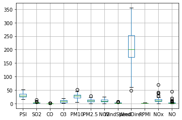

```python
airQty.select_dtypes(include=['int64', 'float64']).boxplot()
plt.show()
```

#### columns 的篩選

```python
airQty.columns
```

```
Index(['SiteName', 'County', 'PSI', 'MajorPollutant', 'Status', 'SO2', 'CO',
       'O3', 'PM10', 'PM2.5', 'NO2', 'WindSpeed', 'WindDirec', 'FPMI', 'NOx',
       'NO', 'PublishTime'],
      dtype='object')
```

```python
airQty['SiteName']            # 挑出單一個 column 就是 Series
```

```
0     麥寮
1     關山
2     馬公
3     金門
4     馬祖
      ..
71    土城
72    新店
73    萬里
74    汐止
75    基隆
Name: SiteName, Length: 76, dtype: object
```

```python
print(airQty['SO2'].mean())
print('------------------------')
print(airQty['SO2'].quantile(q=[0, 0.25, 0.5, 0.75, 1]))
```

```
2.9842105263157905
------------------------
0.00     0.8
0.25     1.9
0.50     2.5
0.75     3.4
1.00    14.0
Name: SO2, dtype: float64
```

```python
# 挑出多個 columns, 仍舊是一個 DataFrame
cols = ['SiteName', 'County', 'PSI', 'MajorPollutant', 'Status', 'SO2']

airQty[cols].head()
```

|  | SiteName | County | PSI | MajorPollutant | Status | SO2 |
| --- | --- | --- | --- | --- | --- | --- |
| 0 | 麥寮 | 雲林縣 | 36 | NaN | 良好 | 1.2 |
| 1 | 關山 | 臺東縣 | 23 | NaN | 良好 | 1.2 |
| 2 | 馬公 | 澎湖縣 | 16 | NaN | 良好 | 0.8 |
| 3 | 金門 | 金門縣 | 32 | NaN | 良好 | 1.4 |
| 4 | 馬祖 | 連江縣 | 39 | NaN | 良好 | 2.8 |

```python
# 排除掉一或多個 columns
cols = ['SiteName', 'County', 'PSI', 'MajorPollutant', 'Status', 'SO2']

airQty.drop(columns=cols, axis=1, inplace=False).head()   # 特別注意 inplace 的參數
```

|  | CO | O3 | PM10 | PM2.5 | NO2 | WindSpeed | WindDirec | FPMI | NOx | NO | PublishTime |
| --- | --- | --- | --- | --- | --- | --- | --- | --- | --- | --- | --- |
| 0 | 0.11 | 10.0 | 35.0 | 7 | 4.5 | 2.2 | 182.0 | 1 | 6.78 | 2.30 | 2016/6/1 02:00 |
| 1 | NaN | 5.1 | 21.0 | 7 | 3.6 | 0.7 | 232.0 | 1 | 4.89 | 1.32 | 2016/6/1 02:00 |
| 2 | 0.09 | 20.0 | 5.0 | 2 | 1.7 | 2.5 | 173.0 | 1 | 3.26 | 1.53 | 2016/6/1 02:00 |
| 3 | 0.08 | 20.0 | 25.0 | 2 | 3.8 | 4.9 | 220.0 | 1 | 4.23 | 0.48 | 2016/6/1 02:00 |
| 4 | 0.08 | 17.0 | 29.0 | 11 | 6.2 | 6.5 | 200.0 | 2 | 7.74 | 1.55 | 2016/6/1 02:00 |

```python
airQty.head()
```

|  | SiteName | County | PSI | MajorPollutant | Status | SO2 | CO | O3 | PM10 | PM2.5 | NO2 | WindSpeed | WindDirec | FPMI | NOx | NO | PublishTime |
| --- | --- | --- | --- | --- | --- | --- | --- | --- | --- | --- | --- | --- | --- | --- | --- | --- | --- |
| 0 | 麥寮 | 雲林縣 | 36 | NaN | 良好 | 1.2 | 0.11 | 10.0 | 35.0 | 7 | 4.5 | 2.2 | 182.0 | 1 | 6.78 | 2.30 | 2016/6/1 02:00 |
| 1 | 關山 | 臺東縣 | 23 | NaN | 良好 | 1.2 | NaN | 5.1 | 21.0 | 7 | 3.6 | 0.7 | 232.0 | 1 | 4.89 | 1.32 | 2016/6/1 02:00 |
| 2 | 馬公 | 澎湖縣 | 16 | NaN | 良好 | 0.8 | 0.09 | 20.0 | 5.0 | 2 | 1.7 | 2.5 | 173.0 | 1 | 3.26 | 1.53 | 2016/6/1 02:00 |
| 3 | 金門 | 金門縣 | 32 | NaN | 良好 | 1.4 | 0.08 | 20.0 | 25.0 | 2 | 3.8 | 4.9 | 220.0 | 1 | 4.23 | 0.48 | 2016/6/1 02:00 |
| 4 | 馬祖 | 連江縣 | 39 | NaN | 良好 | 2.8 | 0.08 | 17.0 | 29.0 | 11 | 6.2 | 6.5 | 200.0 | 2 | 7.74 | 1.55 | 2016/6/1 02:00 |

#### rows(index) 的篩選

```python
airQty['SO2'] <= 3.0
```

```
0      True
1      True
2      True
3      True
4      True
      ...
71    False
72     True
73     True
74     True
75    False
Name: SO2, Length: 76, dtype: bool
```

```python
airQty[airQty['SO2'] <= 1.5]         # 單一個篩選條件
```

|  | SiteName | County | PSI | MajorPollutant | Status | SO2 | CO | O3 | PM10 | PM2.5 | NO2 | WindSpeed | WindDirec | FPMI | NOx | NO | PublishTime |
| --- | --- | --- | --- | --- | --- | --- | --- | --- | --- | --- | --- | --- | --- | --- | --- | --- | --- |
| 0 | 麥寮 | 雲林縣 | 36 | NaN | 良好 | 1.2 | 0.11 | 10.0 | 35.0 | 7 | 4.5 | 2.2 | 182.0 | 1 | 6.78 | 2.30 | 2016/6/1 02:00 |
| 1 | 關山 | 臺東縣 | 23 | NaN | 良好 | 1.2 | NaN | 5.1 | 21.0 | 7 | 3.6 | 0.7 | 232.0 | 1 | 4.89 | 1.32 | 2016/6/1 02:00 |
| 2 | 馬公 | 澎湖縣 | 16 | NaN | 良好 | 0.8 | 0.09 | 20.0 | 5.0 | 2 | 1.7 | 2.5 | 173.0 | 1 | 3.26 | 1.53 | 2016/6/1 02:00 |
| 3 | 金門 | 金門縣 | 32 | NaN | 良好 | 1.4 | 0.08 | 20.0 | 25.0 | 2 | 3.8 | 4.9 | 220.0 | 1 | 4.23 | 0.48 | 2016/6/1 02:00 |
| 7 | 永和 | 新北市 | 37 | NaN | 良好 | 1.3 | 0.36 | 9.7 | 43.0 | 11 | 9.3 | 0.8 | 146.0 | 2 | 12.01 | 2.68 | 2016/6/1 02:00 |
| 13 | 陽明 | 臺北市 | 17 | NaN | 良好 | 1.4 | 0.18 | 20.0 | 16.0 | 10 | 7.9 | NaN | NaN | 1 | 8.47 | 0.60 | 2016/6/1 02:00 |
| 14 | 花蓮 | 花蓮縣 | 29 | NaN | 良好 | 1.1 | 0.16 | 11.0 | 29.0 | 11 | 2.4 | 2.4 | 211.0 | 2 | 3.39 | 0.99 | 2016/6/1 02:00 |
| 15 | 臺東 | 臺東縣 | 23 | NaN | 良好 | 1.0 | 0.19 | 7.5 | 21.0 | 9 | 6.5 | 0.8 | 304.0 | 2 | 7.28 | 0.82 | 2016/6/1 02:00 |
| 16 | 恆春 | 屏東縣 | 20 | NaN | 良好 | 1.4 | 0.05 | 18.0 | 17.0 | 1 | 2.3 | 3.8 | 277.0 | 1 | 4.34 | 2.05 | 2016/6/1 02:00 |
| 31 | 安南 | 臺南市 | 23 | NaN | 良好 | 1.4 | 0.09 | 18.0 | 22.0 | 16 | 0.2 | 2.1 | 216.0 | 1 | 0.14 | -0.01 | 2016/6/1 02:00 |
| 46 | 大里 | 臺中市 | 43 | NaN | 良好 | 1.5 | 0.15 | 11.0 | 31.0 | 2 | 6.8 | 1.7 | 169.0 | 1 | 7.98 | 1.16 | 2016/6/1 02:00 |
| 62 | 古亭 | 臺北市 | 35 | NaN | 良好 | 1.4 | 0.30 | 10.0 | 32.0 | 12 | 8.4 | 1.6 | 180.0 | 2 | 11.01 | 2.58 | 2016/6/1 02:00 |
| 72 | 新店 | 新北市 | 36 | NaN | 良好 | 1.4 | 0.23 | 13.0 | 32.0 | 14 | 5.4 | 3.1 | 173.0 | 2 | 6.72 | 1.35 | 2016/6/1 02:00 |

```python
airQty[(airQty['SO2'] <= 1.5) & (airQty['PM2.5'] <= 5)]         # 多個篩選條件
```

|  | SiteName | County | PSI | MajorPollutant | Status | SO2 | CO | O3 | PM10 | PM2.5 | NO2 | WindSpeed | WindDirec | FPMI | NOx | NO | PublishTime |
| --- | --- | --- | --- | --- | --- | --- | --- | --- | --- | --- | --- | --- | --- | --- | --- | --- | --- |
| 2 | 馬公 | 澎湖縣 | 16 | NaN | 良好 | 0.8 | 0.09 | 20.0 | 5.0 | 2 | 1.7 | 2.5 | 173.0 | 1 | 3.26 | 1.53 | 2016/6/1 02:00 |
| 3 | 金門 | 金門縣 | 32 | NaN | 良好 | 1.4 | 0.08 | 20.0 | 25.0 | 2 | 3.8 | 4.9 | 220.0 | 1 | 4.23 | 0.48 | 2016/6/1 02:00 |
| 16 | 恆春 | 屏東縣 | 20 | NaN | 良好 | 1.4 | 0.05 | 18.0 | 17.0 | 1 | 2.3 | 3.8 | 277.0 | 1 | 4.34 | 2.05 | 2016/6/1 02:00 |
| 46 | 大里 | 臺中市 | 43 | NaN | 良好 | 1.5 | 0.15 | 11.0 | 31.0 | 2 | 6.8 | 1.7 | 169.0 | 1 | 7.98 | 1.16 | 2016/6/1 02:00 |

#### DataFrame 的

- pivot() : 轉置，不計算
- pivot_table() : 轉置，會計算

```python
fname = r'C:\Data\PyData\期中考成績.xlsx'
scores = pd.read_excel(fname, sheet_name=0)
scores.head(10)
```

|  | 學號 | 科目 | 成績 |
| --- | --- | --- | --- |
| 0 | 1 | 國文 | 100 |
| 1 | 2 | 國文 | 80 |
| 2 | 3 | 國文 | 95 |
| 3 | 4 | 國文 | 70 |
| 4 | 5 | 國文 | 90 |
| 5 | 1 | 英文 | 30 |
| 6 | 2 | 英文 | 60 |
| 7 | 3 | 英文 | 80 |
| 8 | 4 | 英文 | 55 |
| 9 | 5 | 英文 | 90 |

```python
scores.pivot(index='學號', columns='科目', values='成績')
```

| 科目 學號 | 國文 | 數學 | 英文 |
| --- | --- | --- | --- |
| 1 | 100 | 66 | 30 |
| 2 | 80 | 88 | 60 |
| 3 | 95 | 77 | 80 |
| 4 | 70 | 50 | 55 |
| 5 | 90 | 90 | 90 |

```python
scores \
    .pivot(index='學號', columns='科目', values='成績') \
    .to_csv(r'C:\Temp\score.csv',sep=',',encoding='utf-8', index=True)
```

```python
fname = r'C:\Data\PyData\產品銷售RawData.xls'
sales = pd.read_excel(fname, sheet_name=1)
sales.head(5)
```

|  | 品牌 | 年度 | 季 | 數量 | 銷售額(萬台幣） |
| --- | --- | --- | --- | --- | --- |
| 0 | 紅基 | 86 | 第一季 | 280 | 1400 |
| 1 | 紅基 | 86 | 第二季 | 265 | 1350 |
| 2 | 紅基 | 86 | 第三季 | 350 | 1500 |
| 3 | 紅基 | 86 | 第四季 | 290 | 1450 |
| 4 | 紅基 | 87 | 第一季 | 260 | 1430 |

```python
sales.pivot_table(index='年度', columns='品牌', values='數量', aggfunc='sum')
# aggfunc : 使用的是 numpy 裡面的 函數
```

| 品牌 年度 | 紅基 | 花碩 | 英特耳 |
| --- | --- | --- | --- |
| 86 | 1185 | 1060 | 1135 |
| 87 | 1080 | 1140 | 1290 |
| 88 | 1260 | 1210 | 1260 |

```python
sales.pivot_table(index='年度', columns='品牌', values='數量', aggfunc='sum',
                  margins=True, margins_name='總計')
# aggfunc : 使用的是 numpy 裡面的 函數
```

| 品牌 年度 | 紅基 | 花碩 | 英特耳 | 總計 |
| --- | --- | --- | --- | --- |
| 86 | 1185 | 1060 | 1135 | 3380 |
| 87 | 1080 | 1140 | 1290 | 3510 |
| 88 | 1260 | 1210 | 1260 | 3730 |
| 總計 | 3525 | 3410 | 3685 | 10620 |

```python
sales \
    .pivot_table(index='年度', columns='品牌', values='數量', aggfunc='sum',
                  margins=True, margins_name='總計') \
    .to_excel(r'C:\Temp\sales.xlsx', sheet_name='銷售分析')
```

#### 物件導向的變化觀念

```python
fname = r'C:\Data\PyData\期中考成績.xlsx'

pd.read_excel(fname, sheet_name=0) \
    .pivot(index='學號', columns='科目', values='成績') \
    .to_csv(r'C:\Temp\score.csv',sep=',',encoding='utf-8', index=True)
```

```python
fname = r'C:\Data\PyData\產品銷售RawData.xls'

pd.read_excel(fname, sheet_name=1) \
    .pivot_table(index='年度', columns='品牌', values='數量', aggfunc='sum',
                  margins=True, margins_name='總計') \
    .to_excel(r'C:\Temp\sales.xlsx', sheet_name='銷售分析')
```

###### DataFrame 的 groupby

- [Python Pandas - GroupBy](https://www.tutorialspoint.com/python_pandas/python_pandas_groupby.htm)

```python
airQty.head()
```

|  | SiteName | County | PSI | MajorPollutant | Status | SO2 | CO | O3 | PM10 | PM2.5 | NO2 | WindSpeed | WindDirec | FPMI | NOx | NO | PublishTime |
| --- | --- | --- | --- | --- | --- | --- | --- | --- | --- | --- | --- | --- | --- | --- | --- | --- | --- |
| 0 | 麥寮 | 雲林縣 | 36 | NaN | 良好 | 1.2 | 0.11 | 10.0 | 35.0 | 7 | 4.5 | 2.2 | 182.0 | 1 | 6.78 | 2.30 | 2016/6/1 02:00 |
| 1 | 關山 | 臺東縣 | 23 | NaN | 良好 | 1.2 | NaN | 5.1 | 21.0 | 7 | 3.6 | 0.7 | 232.0 | 1 | 4.89 | 1.32 | 2016/6/1 02:00 |
| 2 | 馬公 | 澎湖縣 | 16 | NaN | 良好 | 0.8 | 0.09 | 20.0 | 5.0 | 2 | 1.7 | 2.5 | 173.0 | 1 | 3.26 | 1.53 | 2016/6/1 02:00 |
| 3 | 金門 | 金門縣 | 32 | NaN | 良好 | 1.4 | 0.08 | 20.0 | 25.0 | 2 | 3.8 | 4.9 | 220.0 | 1 | 4.23 | 0.48 | 2016/6/1 02:00 |
| 4 | 馬祖 | 連江縣 | 39 | NaN | 良好 | 2.8 | 0.08 | 17.0 | 29.0 | 11 | 6.2 | 6.5 | 200.0 | 2 | 7.74 | 1.55 | 2016/6/1 02:00 |

```python
airQty.groupby(by='County').mean().head()
```

| County | PSI | SO2 | CO | O3 | PM10 | PM2.5 | NO2 | WindSpeed | WindDirec | FPMI | NOx | NO |
| --- | --- | --- | --- | --- | --- | --- | --- | --- | --- | --- | --- | --- |
| 南投縣 | 26.666667 | 2.20 | 0.183333 | 3.5 | 27.0 | 9.0 | 8.00 | 1.033333 | 231.666667 | 1.0 | 9.956667 | 1.95 |
| 嘉義市 | 25.000000 | 2.90 | 0.160000 | 5.5 | 26.0 | 10.0 | 6.80 | 1.100000 | 170.000000 | 1.0 | 8.270000 | 1.49 |
| 嘉義縣 | 37.000000 | 3.05 | 0.210000 | 4.1 | 40.0 | 12.5 | 10.50 | 1.500000 | 167.500000 | 2.0 | 11.700000 | 1.28 |
| 基隆市 | 36.000000 | 3.40 | 0.300000 | 3.7 | 32.0 | 16.0 | 16.00 | 1.100000 | 276.000000 | 2.0 | 19.350000 | 3.04 |
| 宜蘭縣 | 32.500000 | 2.05 | 0.285000 | 6.3 | 33.5 | 11.5 | 10.75 | 0.750000 | 254.500000 | 2.0 | 13.090000 | 2.25 |

```python
airQty.groupby(by='County')['SO2'].min().head(3)
```

```
County
南投縣    1.9
嘉義市    2.9
嘉義縣    2.6
Name: SO2, dtype: float64
```

```python
airQty.groupby(by='County')['SO2'].max().head(3)
```

```
County
南投縣    2.7
嘉義市    2.9
嘉義縣    3.5
Name: SO2, dtype: float64
```

```python
airQty.groupby(by='County').aggregate(['mean', 'sum']).head(3)
# 當一次想要有多個 aggregate function 的計算時，可以使用 .agg() or .aggregate()
```

| County | PSI mean | PSI sum | SO2 mean | SO2 sum | CO mean | CO sum | O3 mean | O3 sum | PM10 mean | PM10 sum | ... | WindSpeed mean | WindSpeed sum | WindDirec mean | WindDirec sum | FPMI mean | FPMI sum | NOx mean | NOx sum | NO mean | NO sum |
| --- | --- | --- | --- | --- | --- | --- | --- | --- | --- | --- | --- | --- | --- | --- | --- | --- | --- | --- | --- | --- | --- |
| 南投縣 | 26.666667 | 80 | 2.20 | 6.6 | 0.183333 | 0.55 | 3.5 | 10.5 | 27.0 | 81.0 | ... | 1.033333 | 3.1 | 231.666667 | 695.0 | 1.0 | 3 | 9.956667 | 29.87 | 1.95 | 5.85 |
| 嘉義市 | 25.000000 | 25 | 2.90 | 2.9 | 0.160000 | 0.16 | 5.5 | 5.5 | 26.0 | 26.0 | ... | 1.100000 | 1.1 | 170.000000 | 170.0 | 1.0 | 1 | 8.270000 | 8.27 | 1.49 | 1.49 |
| 嘉義縣 | 37.000000 | 74 | 3.05 | 6.1 | 0.210000 | 0.42 | 4.1 | 8.2 | 40.0 | 80.0 | ... | 1.500000 | 3.0 | 167.500000 | 335.0 | 2.0 | 4 | 11.700000 | 23.40 | 1.28 | 2.56 |

3 rows × 24 columns

### DataFrame 之摘要資訊

- .info()
- .describe()

```python
airQty.info()
```

```
<class 'pandas.core.frame.DataFrame'>
RangeIndex: 76 entries, 0 to 75
Data columns (total 17 columns):
 #   Column          Non-Null Count  Dtype
---  ------          --------------  -----
 0   SiteName        76 non-null     object
 1   County          76 non-null     object
 2   PSI             76 non-null     int64
 3   MajorPollutant  1 non-null      object
 4   Status          76 non-null     object
 5   SO2             76 non-null     float64
 6   CO              75 non-null     float64
 7   O3              74 non-null     float64
 8   PM10            75 non-null     float64
 9   PM2.5           76 non-null     int64
 10  NO2             76 non-null     float64
 11  WindSpeed       72 non-null     float64
 12  WindDirec       72 non-null     float64
 13  FPMI            76 non-null     int64
 14  NOx             76 non-null     float64
 15  NO              76 non-null     float64
 16  PublishTime     76 non-null     object
dtypes: float64(9), int64(3), object(5)
memory usage: 10.2+ KB
```

```python
airQty.describe()
```

|  | PSI | SO2 | CO | O3 | PM10 | PM2.5 | NO2 | WindSpeed | WindDirec | FPMI | NOx | NO |
| --- | --- | --- | --- | --- | --- | --- | --- | --- | --- | --- | --- | --- |
| count | 76.000000 | 76.000000 | 75.000000 | 74.000000 | 75.000000 | 76.000000 | 76.000000 | 72.000000 | 72.000000 | 76.00000 | 76.000000 | 76.000000 |
| mean | 30.381579 | 2.984211 | 0.225867 | 8.416216 | 27.840000 | 10.223684 | 10.189474 | 2.115278 | 209.375000 | 1.50000 | 13.206447 | 3.041316 |
| std | 8.496222 | 1.907742 | 0.179233 | 5.217779 | 8.625919 | 5.902765 | 5.747245 | 1.605331 | 65.454519 | 0.52915 | 10.467024 | 5.932123 |
| min | 15.000000 | 0.800000 | 0.020000 | 0.800000 | 5.000000 | 0.000000 | 0.200000 | 0.600000 | 48.000000 | 1.00000 | 0.140000 | -0.400000 |
| 25% | 24.000000 | 1.900000 | 0.140000 | 3.825000 | 21.500000 | 6.000000 | 6.650000 | 0.975000 | 172.500000 | 1.00000 | 7.672500 | 0.887500 |
| 50% | 29.000000 | 2.500000 | 0.170000 | 7.600000 | 29.000000 | 10.000000 | 8.850000 | 1.500000 | 201.000000 | 1.00000 | 10.175000 | 1.470000 |
| 75% | 36.000000 | 3.400000 | 0.255000 | 11.750000 | 32.500000 | 14.000000 | 14.000000 | 2.500000 | 253.000000 | 2.00000 | 15.597500 | 2.505000 |
| max | 52.000000 | 14.000000 | 1.180000 | 20.000000 | 51.000000 | 29.000000 | 25.000000 | 7.300000 | 355.000000 | 3.00000 | 70.240000 | 45.200000 |

```python
airQty.describe().T         # 轉置 .T 等同於 .transpose()
```

|  | count | mean | std | min | 25% | 50% | 75% | max |
| --- | --- | --- | --- | --- | --- | --- | --- | --- |
| PSI | 76.0 | 30.381579 | 8.496222 | 15.00 | 24.0000 | 29.000 | 36.0000 | 52.00 |
| SO2 | 76.0 | 2.984211 | 1.907742 | 0.80 | 1.9000 | 2.500 | 3.4000 | 14.00 |
| CO | 75.0 | 0.225867 | 0.179233 | 0.02 | 0.1400 | 0.170 | 0.2550 | 1.18 |
| O3 | 74.0 | 8.416216 | 5.217779 | 0.80 | 3.8250 | 7.600 | 11.7500 | 20.00 |
| PM10 | 75.0 | 27.840000 | 8.625919 | 5.00 | 21.5000 | 29.000 | 32.5000 | 51.00 |
| PM2.5 | 76.0 | 10.223684 | 5.902765 | 0.00 | 6.0000 | 10.000 | 14.0000 | 29.00 |
| NO2 | 76.0 | 10.189474 | 5.747245 | 0.20 | 6.6500 | 8.850 | 14.0000 | 25.00 |
| WindSpeed | 72.0 | 2.115278 | 1.605331 | 0.60 | 0.9750 | 1.500 | 2.5000 | 7.30 |
| WindDirec | 72.0 | 209.375000 | 65.454519 | 48.00 | 172.5000 | 201.000 | 253.0000 | 355.00 |
| FPMI | 76.0 | 1.500000 | 0.529150 | 1.00 | 1.0000 | 1.000 | 2.0000 | 3.00 |
| NOx | 76.0 | 13.206447 | 10.467024 | 0.14 | 7.6725 | 10.175 | 15.5975 | 70.24 |
| NO | 76.0 | 3.041316 | 5.932123 | -0.40 | 0.8875 | 1.470 | 2.5050 | 45.20 |

### DataFrame 之

【區間】

- .loc[ ] : 使用 label
- .iloc[ ] : 使用 index

【單點】

- .at[ ] : 使用 label
- .iat[ ] : 使用 index

```python
airQty.columns
```

```
Index(['SiteName', 'County', 'PSI', 'MajorPollutant', 'Status', 'SO2', 'CO',
       'O3', 'PM10', 'PM2.5', 'NO2', 'WindSpeed', 'WindDirec', 'FPMI', 'NOx',
       'NO', 'PublishTime'],
      dtype='object')
```

```python
airQty.iloc[:3,2:5]
```

|  | PSI | MajorPollutant | Status |
| --- | --- | --- | --- |
| 0 | 36 | NaN | 良好 |
| 1 | 23 | NaN | 良好 |
| 2 | 16 | NaN | 良好 |

```python
airQty.loc[:3,['SiteName', 'County', 'PSI']]
```

|  | SiteName | County | PSI |
| --- | --- | --- | --- |
| 0 | 麥寮 | 雲林縣 | 36 |
| 1 | 關山 | 臺東縣 | 23 |
| 2 | 馬公 | 澎湖縣 | 16 |
| 3 | 金門 | 金門縣 | 32 |

```python
airQty.iat[3,2]
```

```
32
```

```python
airQty.at[3,'County']
```

```
'金門縣'
```

###### DataFrame 的 concat

- rbind() : rows
- cbind() : cols

```python
# (type 1 data)
df1 = pd.DataFrame({'A': ['A0', 'A1', 'A2', 'A3'],
                    'B': ['B0', 'B1', 'B2', 'B3'],
                    'C': ['C0', 'C1', 'C2', 'C3'],
                    'D': ['D0', 'D1', 'D2', 'D3']})

df2 = pd.DataFrame({'A': ['A4', 'A5', 'A6', 'A7'],
                    'B': ['B4', 'B5', 'B6', 'B7'],
                    'C': ['C4', 'C5', 'C6', 'C7'],
                    'D': ['D4', 'D5', 'D6', 'D7']})
```

```python
print(df1)
print(df2)
```

```
    A   B   C   D
0  A0  B0  C0  D0
1  A1  B1  C1  D1
2  A2  B2  C2  D2
3  A3  B3  C3  D3
    A   B   C   D
0  A4  B4  C4  D4
1  A5  B5  C5  D5
2  A6  B6  C6  D6
3  A7  B7  C7  D7
```

#### 小心，以下的結果是錯誤的，因為 index 已經重複

```python
pd.concat([df1, df2], axis=0)     # axis = 0 : R : rbind(), 此語法是錯誤的，要小心
```

|  | A | B | C | D |
| --- | --- | --- | --- | --- |
| 0 | A0 | B0 | C0 | D0 |
| 1 | A1 | B1 | C1 | D1 |
| 2 | A2 | B2 | C2 | D2 |
| 3 | A3 | B3 | C3 | D3 |
| 0 | A4 | B4 | C4 | D4 |
| 1 | A5 | B5 | C5 | D5 |
| 2 | A6 | B6 | C6 | D6 |
| 3 | A7 | B7 | C7 | D7 |

```python
pd.concat([df1, df2], axis=0, verify_integrity=True)
```

[output not shown]

### 非常常用到的上、下合併方式，如同 R 語言的 rbind()

```python
pd.concat([df1, df2], axis=0, verify_integrity=True, ignore_index=True)
```

|  | A | B | C | D |
| --- | --- | --- | --- | --- |
| 0 | A0 | B0 | C0 | D0 |
| 1 | A1 | B1 | C1 | D1 |
| 2 | A2 | B2 | C2 | D2 |
| 3 | A3 | B3 | C3 | D3 |
| 4 | A4 | B4 | C4 | D4 |
| 5 | A5 | B5 | C5 | D5 |
| 6 | A6 | B6 | C6 | D6 |
| 7 | A7 | B7 | C7 | D7 |

```python
pd.concat([df1, df2], axis=1, verify_integrity=True, ignore_index=True)
```

|  | 0 | 1 | 2 | 3 | 4 | 5 | 6 | 7 |
| --- | --- | --- | --- | --- | --- | --- | --- | --- |
| 0 | A0 | B0 | C0 | D0 | A4 | B4 | C4 | D4 |
| 1 | A1 | B1 | C1 | D1 | A5 | B5 | C5 | D5 |
| 2 | A2 | B2 | C2 | D2 | A6 | B6 | C6 | D6 |
| 3 | A3 | B3 | C3 | D3 | A7 | B7 | C7 | D7 |

```python
# (type 2 data : column名稱不同)
df3 = pd.DataFrame({'A': ['A0', 'A1', 'A2', 'A3'],
                    'B': ['B0', 'B1', 'B2', 'B3'],
                    'C': ['C0', 'C1', 'C2', 'C3'],
                    'D': ['D0', 'D1', 'D2', 'D3']})

df4 = pd.DataFrame({'E': ['A4', 'A5', 'A6', 'A7'],
                    'F': ['B4', 'B5', 'B6', 'B7'],
                    'G': ['C4', 'C5', 'C6', 'C7'],
                    'H': ['D4', 'D5', 'D6', 'D7']})
```

```python
print(df3)
print(df4)
```

```
    A   B   C   D
0  A0  B0  C0  D0
1  A1  B1  C1  D1
2  A2  B2  C2  D2
3  A3  B3  C3  D3
    E   F   G   H
0  A4  B4  C4  D4
1  A5  B5  C5  D5
2  A6  B6  C6  D6
3  A7  B7  C7  D7
```

### 常用到的左、右合併方式，如同 R 語言的 cbind()

```python
pd.concat([df3, df4], axis=1, verify_integrity=True)
```

|  | A | B | C | D | E | F | G | H |
| --- | --- | --- | --- | --- | --- | --- | --- | --- |
| 0 | A0 | B0 | C0 | D0 | A4 | B4 | C4 | D4 |
| 1 | A1 | B1 | C1 | D1 | A5 | B5 | C5 | D5 |
| 2 | A2 | B2 | C2 | D2 | A6 | B6 | C6 | D6 |
| 3 | A3 | B3 | C3 | D3 | A7 | B7 | C7 | D7 |

```python
# (type 3 data : index名稱不完全相同)
df5 = pd.DataFrame({'A': ['A0', 'A1', 'A2', 'A3'],
                    'B': ['B0', 'B1', 'B2', 'B3'],
                    'C': ['C0', 'C1', 'C2', 'C3'],
                    'D': ['D0', 'D1', 'D2', 'D3']},
                    index=[0, 1, 2, 3])

df6 = pd.DataFrame({'A': ['A4', 'A5', 'A6', 'A7'],
                    'B': ['B4', 'B5', 'B6', 'B7'],
                    'C': ['C4', 'C5', 'C6', 'C7'],
                    'D': ['D4', 'D5', 'D6', 'D7']},
                     index=[2, 5, 6, 7])
```

```python
print(df5)
print(df6)
```

```
    A   B   C   D
0  A0  B0  C0  D0
1  A1  B1  C1  D1
2  A2  B2  C2  D2
3  A3  B3  C3  D3
    A   B   C   D
2  A4  B4  C4  D4
5  A5  B5  C5  D5
6  A6  B6  C6  D6
7  A7  B7  C7  D7
```

```python
pd.concat([df5, df6], axis=0)                 # 有錯誤
```

|  | A | B | C | D |
| --- | --- | --- | --- | --- |
| 0 | A0 | B0 | C0 | D0 |
| 1 | A1 | B1 | C1 | D1 |
| 2 | A2 | B2 | C2 | D2 |
| 3 | A3 | B3 | C3 | D3 |
| 2 | A4 | B4 | C4 | D4 |
| 5 | A5 | B5 | C5 | D5 |
| 6 | A6 | B6 | C6 | D6 |
| 7 | A7 | B7 | C7 | D7 |

```python
pd.concat([df5, df6], axis=1)                  # 有錯誤
```

|  | A | B | C | D | A | B | C | D |
| --- | --- | --- | --- | --- | --- | --- | --- | --- |
| 0 | A0 | B0 | C0 | D0 | NaN | NaN | NaN | NaN |
| 1 | A1 | B1 | C1 | D1 | NaN | NaN | NaN | NaN |
| 2 | A2 | B2 | C2 | D2 | A4 | B4 | C4 | D4 |
| 3 | A3 | B3 | C3 | D3 | NaN | NaN | NaN | NaN |
| 5 | NaN | NaN | NaN | NaN | A5 | B5 | C5 | D5 |
| 6 | NaN | NaN | NaN | NaN | A6 | B6 | C6 | D6 |
| 7 | NaN | NaN | NaN | NaN | A7 | B7 | C7 | D7 |

### 將 C:\Data\PyData\AirQty(201604) 所有的 csv 讀入，並合併成成一個DataFrame

```python
path_ = r'C:\Data\PyData\AirQty(201604)'
fnames = glob.glob(path_ + r'\**\*.csv', recursive=True)
print(len(fnames))
```

```
30
```

```python
# 初始化:(1)宣告它存在,(2)給定初始值，避免使用到前面舊的資料
df = pd.DataFrame()
for fname in fnames :
    df_new = pd.read_csv(fname, sep=',', encoding='cp950',
                         engine='python')
    df = pd.concat([df, df_new], axis=0 ,
                   verify_integrity=True, ignore_index=True)
print(df.shape)
```

```
(2280, 17)
```

```python
df = pd.concat([pd.read_csv(fname, sep=',', encoding='cp950', engine='python') for fname in fnames],
               axis=0 , verify_integrity=True, ignore_index=True)
print(df.shape)
```

```
(2280, 17)
```

### DataFrame 的 merge (inner、outer、left、right)

pd.merge( left, right, how='inner', on=None, left_on=None, right_on=None, left_index=False, right_index=False, sort=False, suffixes=('_x', '_y'), copy=True, indicator=False, validate=None )

how : {'left', 'right', 'outer', 'inner'}, default 'inner'

- inner : use intersection of keys from both frames, similar to a SQL inner join; preserve the order of the left keys
  - 兩邊皆有的值才會出來
- left : use only keys from left frame, similar to a SQL left outer join; preserve key order
  - 左邊的值會全部出來
- right: use only keys from right frame, similar to a SQL right outer join; preserve key order
  - 右邊的值會全部出來
- outer: use union of keys from both frames, similar to a SQL full outer join; sort keys lexicographically
  - 左、右兩邊的值會全部出來

validate : string, default None. If specified, checks if merge is of specified type.

- "one_to_one" or "1:1": check if merge keys are unique in both left and right datasets.
- "one_to_many" or "1:m": check if merge keys are unique in left dataset.
- "many_to_one" or "m:1": check if merge keys are unique in right dataset.
- "many_to_many" or "m:m": allowed, but does not result in checks.

```python
cust = pd.read_csv(r'C:\Data\PyData\cust.csv',
                   sep=',', encoding='cp950', engine='python')
cust.head(5)
```

|  | 員工代號 | 客戶代號 | 地區代號 |
| --- | --- | --- | --- |
| 0 | 2 | C0005 | A |
| 1 | 2 | C0010 | B |
| 2 | 3 | C0020 | C |
| 3 | 5 | C0025 | D |

```python
emp01 = pd.read_csv(r'C:\Data\PyData\emp01.csv',
                   sep=',', encoding='cp950', engine='python')
emp01.head(5)
```

|  | 員工代號 | 姓名 | 部門 | 職稱 |
| --- | --- | --- | --- | --- |
| 0 | 1 | 陳明明 | 業務部 | 經理 |
| 1 | 2 | 林立人 | 研發部 | 主任 |
| 2 | 3 | 趙銘船 | 研發部 | 專案經理 |
| 3 | 4 | 趙子龍 | 業務部 | 專員 |

```python
emp02 = pd.read_csv(r'C:\Data\PyData\emp02.csv',
                   sep=',', encoding='cp950', engine='python')
emp02.head(5)
```

|  | 員工編號 | 姓名 | 部門 | 職稱 |
| --- | --- | --- | --- | --- |
| 0 | 1 | 陳明明 | 業務部 | 經理 |
| 1 | 2 | 林立人 | 研發部 | 主任 |
| 2 | 3 | 趙銘船 | 研發部 | 專案經理 |
| 3 | 4 | 趙子龍 | 業務部 | 專員 |

```python
pd.merge(left=emp01, right=cust, how='inner', on='員工代號')
```

|  | 員工代號 | 姓名 | 部門 | 職稱 | 客戶代號 | 地區代號 |
| --- | --- | --- | --- | --- | --- | --- |
| 0 | 2 | 林立人 | 研發部 | 主任 | C0005 | A |
| 1 | 2 | 林立人 | 研發部 | 主任 | C0010 | B |
| 2 | 3 | 趙銘船 | 研發部 | 專案經理 | C0020 | C |

```python
pd.merge(left=emp02, right=cust, how='inner',
         left_on='員工編號', right_on='員工代號')
```

|  | 員工編號 | 姓名 | 部門 | 職稱 | 員工代號 | 客戶代號 | 地區代號 |
| --- | --- | --- | --- | --- | --- | --- | --- |
| 0 | 2 | 林立人 | 研發部 | 主任 | 2 | C0005 | A |
| 1 | 2 | 林立人 | 研發部 | 主任 | 2 | C0010 | B |
| 2 | 3 | 趙銘船 | 研發部 | 專案經理 | 3 | C0020 | C |

```python
pd.merge(left=emp01, right=cust, how='left', on='員工代號')
```

|  | 員工代號 | 姓名 | 部門 | 職稱 | 客戶代號 | 地區代號 |
| --- | --- | --- | --- | --- | --- | --- |
| 0 | 1 | 陳明明 | 業務部 | 經理 | NaN | NaN |
| 1 | 2 | 林立人 | 研發部 | 主任 | C0005 | A |
| 2 | 2 | 林立人 | 研發部 | 主任 | C0010 | B |
| 3 | 3 | 趙銘船 | 研發部 | 專案經理 | C0020 | C |
| 4 | 4 | 趙子龍 | 業務部 | 專員 | NaN | NaN |

```python
pd.merge(left=emp01, right=cust, how='right', on='員工代號')
```

|  | 員工代號 | 姓名 | 部門 | 職稱 | 客戶代號 | 地區代號 |
| --- | --- | --- | --- | --- | --- | --- |
| 0 | 2 | 林立人 | 研發部 | 主任 | C0005 | A |
| 1 | 2 | 林立人 | 研發部 | 主任 | C0010 | B |
| 2 | 3 | 趙銘船 | 研發部 | 專案經理 | C0020 | C |
| 3 | 5 | NaN | NaN | NaN | C0025 | D |

### Categorical (類別資料)

- Norminal Scales
- Ordinal Scales
- Interval Scales
- Ratio Scales

#### Norminal

```python
data = ['high','medium','medium','low','high']
```

```python
data_nom = pd.Categorical(data,
                          categories=['low', 'medium', 'high'],
                          ordered=False)
data_nom
```

```
['high', 'medium', 'medium', 'low', 'high']
Categories (3, object): ['low', 'medium', 'high']
```

#### Ordinal

```python
data = ['high','medium','medium','low','high']
```

```python
data_ordinal = pd.Categorical(data,
                              categories=['low', 'medium', 'high'],
                              ordered=True)
data_ordinal
```

```
['high', 'medium', 'medium', 'low', 'high']
Categories (3, object): ['low' < 'medium' < 'high']
```

```python
data_ordinal[data_ordinal >= 'medium']
```

```
['high', 'medium', 'medium', 'high']
Categories (3, object): ['low' < 'medium' < 'high']
```

### 解決pivot_table()排序的問題

- 季節排序順序

```python
fname = r'C:\Data\PyData\產品銷售RawData.xls'

pd.read_excel(fname, sheet_name=1) \
    .pivot_table(index=['年度', '季'],
                 columns='品牌',
                 values='數量',
                 aggfunc='sum',
                 margins=True,
                 margins_name='總計')
```

| 年度 | 品牌 季 | 紅基 | 花碩 | 英特耳 | 總計 |
| --- | --- | --- | --- | --- | --- |
| 86 | 第一季 | 280 | 240 | 290 | 810 |
|  | 第三季 | 350 | 280 | 290 | 920 |
|  | 第二季 | 265 | 250 | 285 | 800 |
|  | 第四季 | 290 | 290 | 270 | 850 |
| 87 | 第一季 | 260 | 240 | 310 | 810 |
|  | 第三季 | 290 | 300 | 350 | 940 |
|  | 第二季 | 250 | 280 | 290 | 820 |
|  | 第四季 | 280 | 320 | 340 | 940 |
| 88 | 第一季 | 270 | 260 | 290 | 820 |
|  | 第三季 | 350 | 310 | 340 | 1000 |
|  | 第二季 | 310 | 300 | 270 | 880 |
|  | 第四季 | 330 | 340 | 360 | 1030 |
| 總計 |  | 3525 | 3410 | 3685 | 10620 |

```python
fname = r'C:\Data\PyData\產品銷售RawData.xls'
sales = pd.read_excel(fname, sheet_name=1)

sales.head()

sales['季'] = pd.Categorical(sales['季'],
                             categories=['第一季', '第二季', '第三季', '第四季'],
                             ordered=True)

print(sales.dtypes)

sales.pivot_table(index=['年度', '季'],
                  columns='品牌',
                  values='數量',
                  aggfunc='sum',
                  margins=True,
                  margins_name='總計')
```

```
品牌            object
年度             int64
季           category
數量             int64
銷售額(萬台幣）       int64
dtype: object
```

| 年度 | 品牌 季 | 紅基 | 花碩 | 英特耳 | 總計 |
| --- | --- | --- | --- | --- | --- |
| 86 | 第一季 | 280 | 240 | 290 | 810 |
|  | 第二季 | 265 | 250 | 285 | 800 |
|  | 第三季 | 350 | 280 | 290 | 920 |
|  | 第四季 | 290 | 290 | 270 | 850 |
| 87 | 第一季 | 260 | 240 | 310 | 810 |
|  | 第二季 | 250 | 280 | 290 | 820 |
|  | 第三季 | 290 | 300 | 350 | 940 |
|  | 第四季 | 280 | 320 | 340 | 940 |
| 88 | 第一季 | 270 | 260 | 290 | 820 |
|  | 第二季 | 310 | 300 | 270 | 880 |
|  | 第三季 | 350 | 310 | 340 | 1000 |
|  | 第四季 | 330 | 340 | 360 | 1030 |
| 總計 |  | 3525 | 3410 | 3685 | 10620 |

```python
sales['季'].dtype
```

```
CategoricalDtype(categories=['第一季', '第二季', '第三季', '第四季'], ordered=True)
```